# Informe estadístico sobre la brecha laboral en cuestiones de género en Argentina (1982-2018)

Patricia Perrone y Marianela Pi

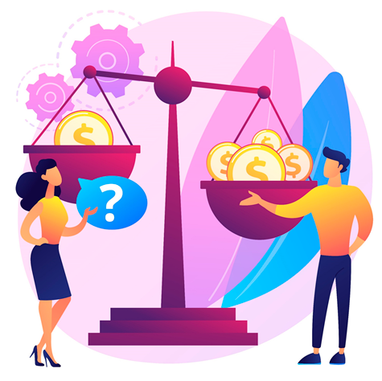

# Introducción

# Exploración de los datos

Los datos utilizados en este informe fueron tomados por el Banco Mundial sobre empleo/desempleo y género para algunos países de Latinoamérica y el Caribe, entre los años 1970 y 2018. Estos datos fueron provistos en formato de *data-frame* y contienen una cantidad de variables que aportan datos sobre el empleo/desempleo, tipo de empleo/actividad y legislación.

Para ajustar los datos al alcance de este análisis, se utilizarán sólo los datos de Argentina comprendidos entre los años 1982 y 2018, que es el período en donde Argentina relevó datos. Fuera de ese período no hay información disponible.

```r
# Código para cargar o leer los datos
# Filtramos por país (Argentina) y eliminamos las columnas de años que no tienen datos para simplificar el análisis

empleo_genero <- read.csv("datos/empleo_genero.csv")  |>
  filter(pais_region=="Argentina")  |>
  select(-pais_region, -codigo_pais_region)

empleo_genero <- empleo_genero[,-which(colMeans(is.na(empleo_genero)) == 1)]

# Transposición de los datos de la tabla
empleo_Arg <- pivot_longer(empleo_genero,
                           cols=2:36,
                           names_to = "Anio",
                           values_to = "porcentaje")

# reemplazo los valores de los años por el número correspondiente
# Convierto Anio a numérico

empleo_Arg <- empleo_Arg |>
  mutate(Anio = str_replace(Anio,"X",""),
         Anio = as.numeric(Anio))

# Llevamos la tabla a formato Tidy
empleo_Arg_ancho <- pivot_wider(empleo_Arg,
                                names_from = variable,
                                values_from = porcentaje)


 # Comparación del desempleo por género, filtro variable por desempleo y agrego columna con el sexo
 desempleo_calificado <- filter(empleo_Arg,variable %in% c("desempleo_educacion_mujeres","desempleo_educacion_hombres"))  |>
             mutate(sexo = ifelse(variable == "desempleo_educacion_mujeres","Mujer","Hombre"))

# # Retiro los años sin datos para acortar el gráfico
 desempleo_calificado <- filter(desempleo_calificado, Anio > "2000")


# Comparación del desempleo por género, filtro variable por desempleo y agrego columna con el sexo
desempleo <- dplyr::filter(empleo_Arg,variable %in% c("desempleo_mujeres","desempleo_hombres"))  |>

             mutate(sexo = ifelse(variable == "desempleo_mujeres","Mujer","Hombre"))


 tipo_empleo <- dplyr::filter(empleo_Arg,variable %in% c("empleo_agricultura_mujeres","empleo_agricultura_hombres","empleo_industria_mujeres","empleo_industria_hombres","empleo_servicios_mujeres","empleo_servicios_hombres","empleo_informal_mujeres","empleo_informal_hombres","autoempleo_mujeres","autoempleo_hombres"))  |>
               mutate(sexo = ifelse(str_detect(variable,"mujeres"),"Mujer","Hombre"))  |>
               mutate(tipo = substring(variable,8,str_length(variable)-8))

# Corrijo el "autoempleo"
tipo_empleo$tipo <- str_replace(tipo_empleo$tipo, "leo", "autoempleo")



 empleo_domestico <- dplyr::filter(empleo_Arg,variable %in% c("trabajo_domestico_no_remunerado_mujeres","trabajo_domestico_no_remunerado_hombres")) |>
                    mutate(sexo = ifelse(variable == "trabajo_domestico_no_remunerado_mujeres","Mujer","Hombre"))

# Retiro los años sin datos para acortar el gráfico
empleo_domestico <- dplyr::filter(empleo_domestico, Anio > "2003")

empleadores <- dplyr::filter(empleo_Arg, variable %in% c("empleadoras_mujeres","empleadores_hombres")) %>%
    mutate(sexo = ifelse(variable == "empleadoras_mujeres","Mujer","Hombre"))

 # Comparo las variables desempleo con empleo calificado eliminando los años que no tienen datos
 Jefes_vs_desempleocal <- union(empleadores, desempleo_calificado) %>%    filter(Anio > 1990)

 # Calculo las medias por variable
 mjefesdescal <- Jefes_vs_desempleocal %>%
   group_by(variable) %>%
      summarise(media = mean(porcentaje,na.rm = TRUE))

 # Busco la distribución de la ocupación de las mujeres
  actividades_mujeres <- empleo_Arg %>%
    mutate(sexo = ifelse(str_detect(variable,"mujeres"),"Mujer","Hombre")) %>%
    filter(sexo == "Mujer") %>%
    filter(variable != "empleadoras_mujeres" & variable != "desempleo_educacion_mujeres") %>%
    group_by(variable) %>%
    summarise(media = mean(porcentaje,na.rm = TRUE))

# Gráfico 1

  # Busco la distribución de la ocupación de las mujeres
  actividades_mujeres <- empleo_Arg %>%
    mutate(sexo = ifelse(str_detect(variable,"mujeres"),"Mujer","Hombre")) %>%
    filter(sexo == "Mujer") %>%
    filter(variable != "empleo_servicios_mujeres" & variable != "empleadores_hombres") %>%
    group_by(variable) %>%
    summarise(media = mean(porcentaje,na.rm = TRUE))

  empleo_genero1 <- empleo_Arg %>%
  # creo una columna de sexo según el dato de la columna variable
  mutate(sexo = ifelse(endsWith(variable, "_mujeres"), "mujer", ifelse(endsWith(variable, "_hombres"), "hombre", ""))) %>%
  # y ahora se lo extraigo y renombro la columna a fuerza laboral
  rename("variable" = "variable") %>%
  mutate(variable = str_remove(variable, c("_mujeres"))) %>%
  mutate(variable = str_remove(variable, c("_hombres")))  %>%
  # ordeno las columnas y dejo afuera las que no necesito (en este caso, en la variable país, me quedo solo con el código ISO)
  select(c( Anio, variable, sexo, porcentaje))



  EmpleoAR1 <- gt(head(empleo_genero1,10)) |>
      tab_header(title = md("**Distribución del empleo en Argentina**"),
                 subtitle = "Años 1982 a 2018") |>
      cols_label(Anio = "Año", variable = "Variable", sexo = "Sexo",
                 porcentaje = "Porcentaje %") |>
    cols_align(align = "center", columns = everything()) |>
    fmt_number(
      columns = 4:4,
      decimals = 2,
      dec_mark = ",",
      sep_mark = ".") |>
    tab_options(
    table.border.top.color = "white",
    column_labels.border.top.width = px(3),
    column_labels.border.top.color = "black",
    ) |>
    tab_source_note(md("*Fuente: Banco Mundial sobre empleo/desempleo y género para Latinoamérica y Caribe (1970 a 2018)*"))


# EmpleoAR <- gt(head(empleo_Arg_ancho,5)) |>
#       tab_header(title = md("**Distribución del empleo en Argentina**"),
#                  subtitle = md("Años 1982 a 2018")) |>
#       cols_label(Anio = "Año", empleadoras_mujeres = "Empleadoras", empleadores_hombres = "Empleadores",
#                  empleo_agricultura_mujeres = "Agricultura M", empleo_agricultura_hombres = "Agricultura H",
#                  empleo_industria_mujeres = "Industria M", empleo_industria_hombres = "Industria H",
#                  empleo_servicios_mujeres = "Servicios M", empleo_servicios_hombres    = "Servicios H",
#                  empleo_informal_mujeres ="Informal M", empleo_informal_hombres = "Informal H",
#                  legislacion_acoso_sexual = "Legislación Acoso",
#                  autoempleo_mujeres = "Autoempleo M", autoempleo_hombres = "Autoempleo H",
#                  empleo_parcial_mujeres = "Parcial M",
#                  desempleo_educacion_mujeres = "Desempleo calificado M",
#                  desempleo_educacion_hombres = "Desempleo calificado H",
#                  desempleo_mujeres = "Desempleo M", desempleo_hombres = "Desempleo H",
#                  trabajo_domestico_no_remunerado_mujeres = "Trab Domestico M",
#                  trabajo_domestico_no_remunerado_hombres = "Trab doméstico H") |>
#     cols_align(align = "center", columns = everything()) |>
#     fmt_number(
#       columns = 2:21,
#       decimals = 2,
#       dec_mark = ",",
#       sep_mark = ".") |>
#     tab_options(
#     table.border.top.color = "white",
#     column_labels.border.top.width = px(3),
#     column_labels.border.top.color = "black",
#     ) |>
#     tab_source_note(md("*Fuente: Banco Mundial sobre empleo/desempleo y género para Latinoamérica y Caribe (1970 a 2018)*"))
```

## Descripción y cantidad de observaciones

En la tabla que sigue podemos ver el aspecto general del conjunto de datos con el que trabajaremos, de 4 variables y 700 observaciones que muestra la distribución del empleo y el desempleo en Argentina por género y la existencia o no de legislación sobre el acoso sexual. Los datos se muestran como porcentajes.

```r
EmpleoAR1
```

**Distribución del empleo en Argentina**

Años 1982 a 2018

| Año | Variable | Sexo | Porcentaje % |
| --- | --- | --- | --- |
| 1982 | empleadoras | mujer | NA |
| 1983 | empleadoras | mujer | NA |
| 1984 | empleadoras | mujer | NA |
| 1987 | empleadoras | mujer | NA |
| 1988 | empleadoras | mujer | NA |
| 1989 | empleadoras | mujer | NA |
| 1990 | empleadoras | mujer | NA |
| 1991 | empleadoras | mujer | 2,06 |
| 1992 | empleadoras | mujer | 2,46 |
| 1993 | empleadoras | mujer | 3,20 |

*Fuente: Banco Mundial sobre empleo/desempleo y género para Latinoamérica y Caribe (1970 a 2018)*

## Desempleo

¿Por qué debería preocuparnos la brecha de género en lo laboral? La libertad de trabajar, por decisión propia y en condiciones de dignidad, seguridad y equidad, es esencial para el bienestar humano. Garantizar que la mujer goce de este derecho es un objetivo importante en sí mismo.

```r
# Cálculo de estadísticos
mdesempleo <- desempleo  |>  group_by(variable)  |>
  summarise(media = mean(porcentaje,na.rm = TRUE),
            desvio = sd(porcentaje,na.rm = TRUE))

Desempleo <- mdesempleo |>
  gt(empleo_Arg_ancho,10) |>
  tab_header(title = md("**Desempleo por género en Argentina**")) |>
  cols_label(variable = "Desempleo por género", media = "Pormedio (%)", desvio = "Desvío") |>
  fmt_number(
      columns = c(media, desvio),
      decimals = 2,
      dec_mark = ",",
      sep_mark = ".") |>
    tab_options(
    table.border.top.color = "white",
    column_labels.border.top.width = px(3),
    column_labels.border.top.color = "black",
    heading.border.bottom.color = "black")



Desempleo
```

**Desempleo por género en Argentina**

| Desempleo por género | Pormedio (%) | Desvío |
| --- | --- | --- |
| desempleo_hombres | 9,92 | 4,63 |
| desempleo_mujeres | 12,22 | 5,19 |

Aquí tenemos la comparación del desempleo por año y género, utilizando dos gráficos diferentes (barras y líneas).

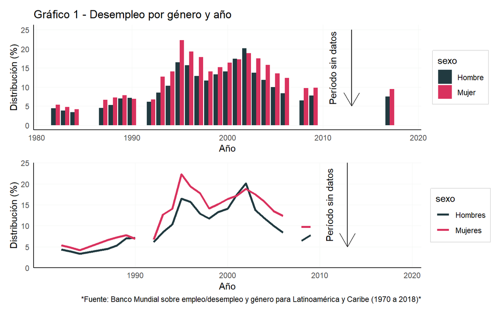

```r
G1_1 <- ggplot(desempleo,aes(Anio,porcentaje, fill = sexo)) + geom_col(position=position_dodge()) +
  scale_fill_manual(values=c("#213A40", "#D9325E")) +
  theme_classic() +
  theme(axis.text.x = element_text(size = 9),
        axis.text.y = element_text(size = 9),
        legend.position = "right",
        legend.box.background= element_rect(color = "grey"),
        axis.ticks = element_blank(),
        panel.grid = element_blank(),
        panel.grid.major.x = element_line(size=0.05, color = "#f2f5f3"),
        panel.grid.major.y = element_line(size=0.05, color = "#f2f5f3")) +
  labs(title = "Gráfico 1 - Desempleo por género y año", x = "Año", y = "Distribución (%)") +
  annotate("text", x = 2011, y = 15, angle = 90,label = "Período sin datos") +
  annotate("segment", x = 2013, xend = 2013, y = 25, yend = 5,  arrow = arrow()) +
  annotate("rect", xmin = 2001, xmax = 2001, ymin = 17, ymax = 21, alpha = 0.3)

  G1_2 <- ggplot(desempleo,aes(Anio,porcentaje)) +
  geom_line(aes(color = sexo),lwd = 1.2)+
  scale_y_continuous(limits=c(0,25), breaks = c(0,5,10,15,20,25), expand = c(0, 0)) +
  scale_x_continuous(limits=c(1980,2020),breaks = c(1990,2000,2010,2020), expand = c(0,1))+
  scale_color_manual(labels = c("Hombres", "Mujeres"), values = c("#213A40", "#D9325E"))+
  theme_classic()+
  theme(axis.text.x = element_text(size = 9),
        axis.text.y = element_text(size = 9),
        legend.position = "right",
        legend.box.background= element_rect(color = "grey"),
        axis.ticks = element_blank(),
        panel.grid = element_blank(),
        panel.grid.major.x = element_line(size=0.05, color = "#f2f5f3"),
        panel.grid.major.y = element_line(size=0.05, color = "#f2f5f3")) +
  annotate("text", x = 2011, y = 15, angle = 90,
        label = "Período sin datos") +
  annotate("segment", x = 2013, xend = 2013, y = 25, yend = 5,  arrow = arrow()) +
  annotate("rect", xmin = 2001, xmax = 2001, ymin = 17, ymax = 21, alpha = .3)   +
    labs(x = "Año", y = "Distribución (%)",
         caption = "*Fuente: Banco Mundial sobre empleo/desempleo y género para Latinoamérica y Caribe (1970 a 2018)*")



  mdesempleo <- desempleo  |>
   group_by(variable) |>
   summarise(media = mean(porcentaje,na.rm = TRUE))

 mdesempleo2 <- mdesempleo |>
   mutate(csum = rev(cumsum(rev(media))),
          pos = media/2 + lead(csum, 1),
         pos = if_else(is.na(pos), media/2, pos),
          media = round(media, 2))


 G1_1 / G1_2
```

Con cualquiera de los gráficos podemos ver que a lo largo de los años, este comportamiento se mantiene, registrándose una diferencia importante entre los porcentajes de desempleo.

## Tipos de actividad

Esta tabla contiene información sobre el tipo de actividad realizada en el empleo. También está por género y año. Una observación a tener en cuenta es que, si bien se releva el empleo parcial para las mujeres, no se relevó para los hombres. Debido a que esta variable no puede ser comparada.

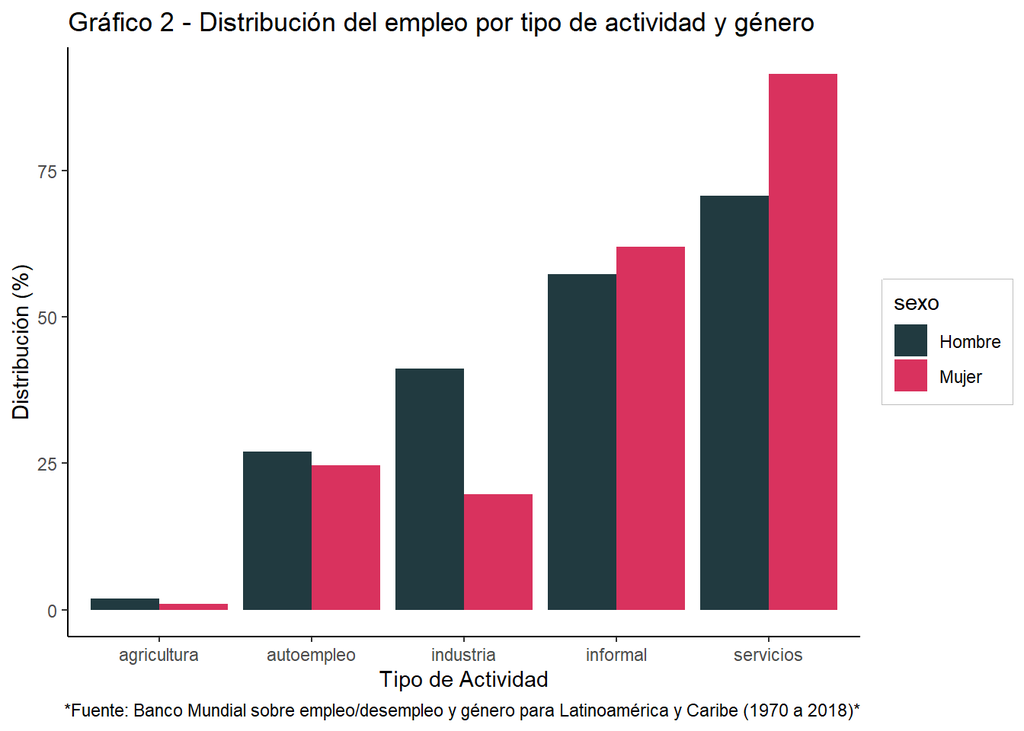

```r
# Grafico por tipo de actividad

G2 <- ggplot(tipo_empleo,aes(tipo,porcentaje, fill = sexo)) +
  geom_col(position=position_dodge()) +
  scale_fill_manual(values=c("#213A40", "#D9325E")) +
  theme_classic() +
  theme(legend.box.background= element_rect(color = "grey")) +
  labs(title = "Gráfico 2 - Distribución del empleo por tipo de actividad y género",
       x = "Tipo de Actividad", y = "Distribución (%)",
       caption = "*Fuente: Banco Mundial sobre empleo/desempleo y género para Latinoamérica y Caribe (1970 a 2018)*")

G2
```

## Desempleo calificado

La población de mujeres con nivel terciario desempleadas llega casi al 6%, mientras que los varones apenas superan el 4%. Si bien las credenciales educativas de las mujeres parecieran favorecer su participación en el mercado de trabajo, cuando analizamos los datos como mujeres trabajadoras sigue en evidencia la situación de desventaja para ellas.

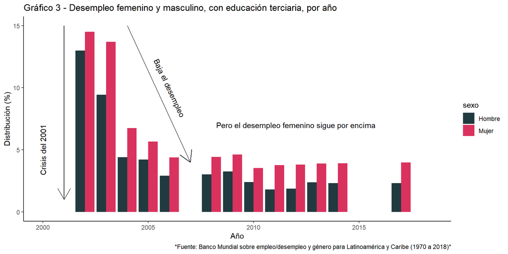

```r
# Gráfico de desempleo calificado

G3 <- ggplot(desempleo_calificado,aes(Anio,porcentaje, fill = sexo, na.rm = TRUE)) +
  theme_classic()+
  geom_col(position=position_dodge()) +
  scale_fill_manual(values=c("#213A40", "#D9325E")) +
  labs(title = "Gráfico 3 - Desempleo femenino y masculino, con educación terciaria, por año",
       x = "Año", y = "Distribución (%)",
       caption = "*Fuente: Banco Mundial sobre empleo/desempleo y género para Latinoamérica y Caribe (1970 a 2018)*") +
  annotate("text", x = 2000, y = 5, angle = 90,
        label = "Crisis del 2001") +
  annotate("segment", x = 2001, xend = 2001, y = 15, yend = 1,  arrow = arrow()) +
  annotate("text", x = 2006, y = 10, angle = -65,
        label = "Baja el desempleo") +
  annotate("segment", x = 2004, xend = 2007, y = 15, yend = 4,  arrow = arrow()) +
  annotate("text", x = 2012, y = 7, angle = 0,
        label = "Pero el desempleo femenino sigue por encima")

G3
```

## Empleadores por género

Quizás viendo los datos anteriores uno pensaría que esa brecha puede originarse en la falta de educación o que los hombres están más preparados académicamente que las mujeres y de esa manera tener más oportunidades en el campo laboral dejando de lado la famosa teoría del techo de cristal, esa barrera invisible que impide que las mujeres alcancen las mismas posiciones de poder que los hombres y que está relacionada directamente con las normas y los estereotipos. Ahí nos surgen las siguientes preguntas **¿Las mujeres con el mismo nivel académico que los hombres tienen las mismas oportunidades de ocupar un puesto jerárquico?, ¿y cuando hablamos de cargos jerárquicos? ¿qué tanta diferencia hay entre los ingresos de los hombres y de las mujeres?**

Si bien el desempleo calificado es generalizado tanto para la mujer como para el hombre, la mujer tiende a tener un índice mayor de desempleo generando una brecha porcentual del 1.81. Viendo este número uno pensaría que la brecha de empleadores/as estaría rondando en un porcentaje similar si existiesen las mismas oportunidades.

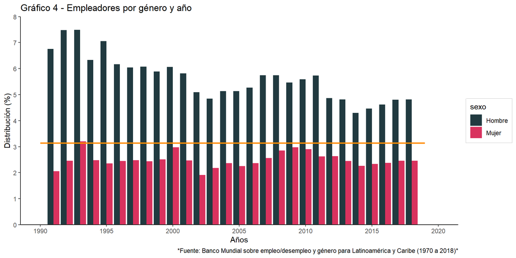

```r
G4 <- ggplot(empleadores, aes(Anio,porcentaje, fill = sexo, na.rm = TRUE)) +
  geom_col(position=position_dodge()) +
  scale_fill_manual(values=c("#213A40", "#D9325E")) +
  scale_color_manual(labels= c("Hombres","Mujeres"), values = c("#213A40", "#D9325E"))+
  labs(title = "Gráfico 4 - Empleadores por género y año", x = "Años", y = "Distribución (%)", color = "Sexo",
       caption = "*Fuente: Banco Mundial sobre empleo/desempleo y género para Latinoamérica y Caribe (1970 a 2018)*")+
  scale_x_continuous(limits=c(1990,2020), breaks = c(1990,1995,2000,2005,2010,2015,2020)) +
  scale_y_continuous(limits = c(0,8), breaks = c(seq(0,8,1)), expand = c(0,0)) +
  annotate("segment", x = 1990, xend = 2019, y = 3.14, yend = 3.14, color = "darkorange", size = 1) +
  theme_classic() +
  theme(legend.box.background= element_rect(color = "grey"))


G4
```

El porcentual de empleadores/as alcanza el 3.13 % cuando la diferencia de desempleo nivel terciario como mencionamos anteriormente era del 1.81 % y eso muestra la desventaja que existe entre el hombre y la mujer a la hora de tener oportunidades laborales,como también de ser considerada para un puesto jerárquico.

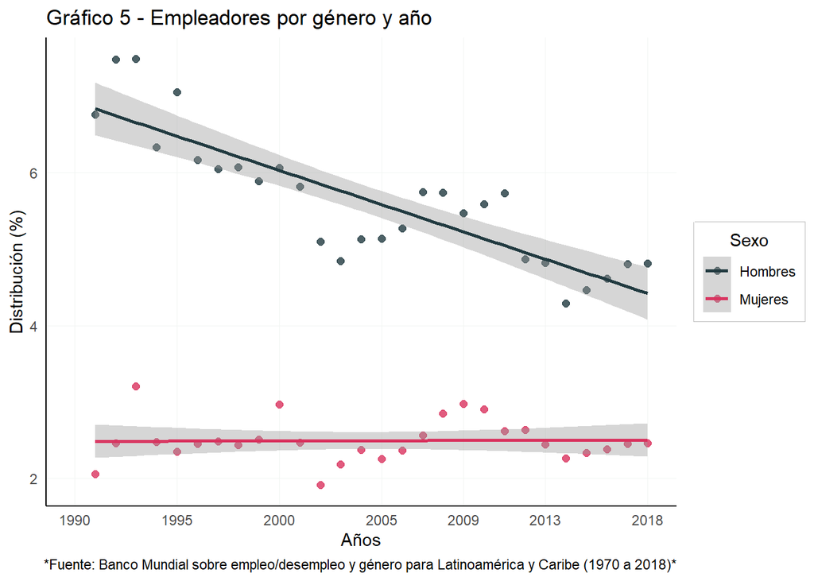

```r
G5 <-empleadores %>%
  group_by(factor(sexo)) %>%
  ggplot(aes(Anio,porcentaje))+
  geom_point(aes(color=factor(sexo)), size=2, alpha = 0.8)+
  geom_smooth(aes(color=sexo), span=0.8, method = "lm")+
  scale_color_manual(labels= c("Hombres","Mujeres"), values = c("#213A40", "#D9325E"))+
  labs(title = "Gráfico 5 - Empleadores por género y año", x = "Años", y = "Distribución (%)", color = "Sexo",
       caption = "*Fuente: Banco Mundial sobre empleo/desempleo y género para Latinoamérica y Caribe (1970 a 2018)*")+
  scale_x_continuous(limits=c(1990,2018),breaks = c(1990,1995,2000,2005,2009,2013,2018)) +
  theme_classic()+
  theme(axis.text.x = element_text(size = 9),
        axis.text.y = element_text(size = 9),
        legend.title.align = 0.5,
        legend.box.background= element_rect(color = "grey"),
        axis.ticks = element_blank(),
        panel.grid = element_blank(),
        panel.grid.major.x = element_line(size=0.05, color = "#f2f5f3"),
        panel.grid.major.y = element_line(size=0.05, color = "#f2f5f3"))


G5
```

En el gráfico 5 - Empleadores por género y año podemos observar algo bastante particular, y es que, mientras el porcentaje promedio de empleadores tiene una clara caída con una pendiente bien marcada, el porcentaje de empleadoras se mantuvo bastante estable a través de los años observados, a pesar de que mostró una inflexión similar entre los años 2005 y 2007 aproximadamente. Si bien no tenemos datos suficientes para demostrarlo, nuestra sospecha es que la misma desigualdad ha provocado que las mujeres que logran alcanzar un puesto de jefas, lo hagan con mucha más solidez que los hombres, lo que en épocas de inestabilidad económica se traduzca en una menor caída en esos puestos de trabajo. Otro dato notable para destacar es que a pesar de existir una caida pronunciada en el porcentaje empleadores hombres, no existe una subida pronunciada en empleadoras mujeres que indique que fueron adquiriendo más oportunidades, por el contrario se mantuvo estable.

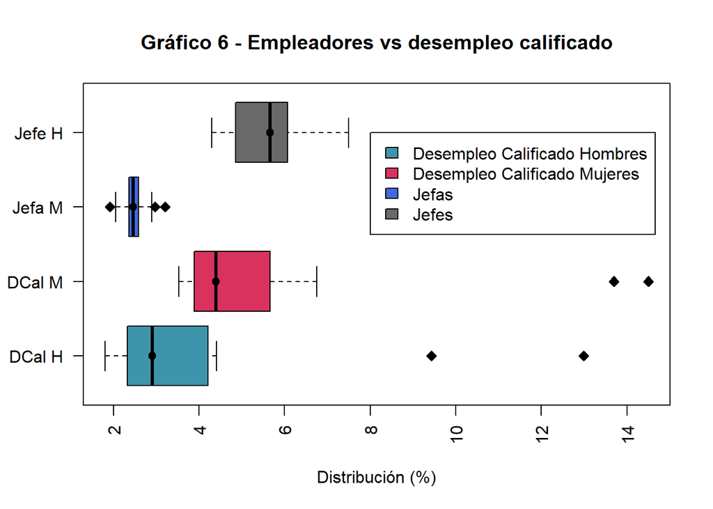

```r
Jefes_vs_desempleocal$variable <- str_replace(Jefes_vs_desempleocal$variable, "mujeres", " M")
Jefes_vs_desempleocal$variable <- str_replace(Jefes_vs_desempleocal$variable, "hombres", " H")
Jefes_vs_desempleocal$variable <- str_replace(Jefes_vs_desempleocal$variable, "desempleo_educacion_", "DCal")
Jefes_vs_desempleocal$variable <- str_replace(Jefes_vs_desempleocal$variable, "empleadores_", "Jefe")
Jefes_vs_desempleocal$variable <- str_replace(Jefes_vs_desempleocal$variable, "empleadoras_", "Jefa")

G6 <- boxplot(Jefes_vs_desempleocal$porcentaje ~ Jefes_vs_desempleocal$variable,
        horizontal = TRUE,
        col = c("#3E95AB","#D9325E", "#4169E1", "#696969"),
        outbg = "black",
        outpch = 23,
        ylab = "",
        xlab = "Distribución (%)",
        las = 2,
        medpch = 19,
        medcex = 1,
        medbg = 1)

title ("Gráfico 6 - Empleadores vs desempleo calificado")


  legend(8, 4, c("Desempleo Calificado Hombres", "Desempleo Calificado Mujeres", "Jefas", "Jefes"),
       fill = c("#3E95AB","#D9325E", "#4169E1", "#696969"))
```

El gráfico 6 no sólo confirma sino que amplía lo que podemos observar en el gráfico 5. La dispersión en la variable jefas_mujeres es muy pequeña y casi todos los valores están muy cercanos a la media. Ni siquiera los valores extremos se apartan demasiado, a diferencia del caso de jefes_hombres.

# Conclusiones